# Final Project

Chiemeziem Oguayo, Rhys Leahy, Chaoran Jin (Julia), Patrick Junghenn

2021-12-14

# Introduction

Advertising drives business, but even with advances in social media and advertising technology, we have a limited understanding of what influences customers to buy or not buy a certain product. If companies could predict whether an advertising campaign is likely to influence a potential customer to buy their product, they could more effectively target their campaigns to the most receptive customers, decrease their marketing costs, and increase their revenue.

To put these goals into practice, we analyzed a Portuguese bank’s marketing campaign that took place between May 2008 and November 2010. During the campaign, telemarketers called potential customers to persuade them to subscribe to a bank term deposit. During these calls, they recorded key demographic information such as age, job, marital and education status. Telemarketers also noted information about customers’ current accounts like balance, housing, loan, and default records, as well as data about the campaign itself including the timing and duration of their call. Critically, they also documented the outcome of their efforts: whether or not a potential customer subscribed to the bank term deposit. Using this dataset, we worked to answer the following questions:

- Can we build a model that predicts whether or not bank customers are likely to subscribe to a term deposit despite a largely unbalanced dataset?
- Given an unbalanced dataset, how much does a model built from a balanced dataset improve from the original model?

By developing a model that effectively predicts whether or not a customer is likely to subscribe to a certain product, we can help this Portuguese bank more effectively target their advertising efforts with the ultimate goal of decreasing their marketing costs and increasing their subscription rates and revenue.

# Dataset dictionary

bank client data:

1 - age (numeric)

2 - job : type of job (categorical: “admin.”,“unknown”,“unemployed”,“management”,“housemaid”,“entrepreneur”,“student”, “blue-collar”,“self-employed”,“retired”,“technician”,“services”)

3 - marital : marital status (categorical: “married”,“divorced”,“single”; note: “divorced” means divorced or widowed)

4 - education (categorical: “unknown”,“secondary”,“primary”,“tertiary”)

5 - default: has credit in default? (binary: “yes”,“no”)

6 - balance: average yearly balance, in euros (numeric)

7 - housing: has housing loan? (binary: “yes”,“no”)

8 - loan: has personal loan? (binary: “yes”,“no”)

related with the last contact of the current campaign:

9 - contact: contact communication type (categorical: “unknown”,“telephone”,“cellular”)

10 - day: last contact day of the month (numeric)

11 - month: last contact month of year (categorical: “jan”, “feb”, “mar”, …, “nov”, “dec”)

12 - duration: last contact duration, in seconds (numeric)

other attributes:

13 - campaign: number of contacts performed during this campaign and for this client (numeric, includes last contact)

14 - pdays: number of days that passed by after the client was last contacted from a previous campaign (numeric, -1 means client was not previously contacted)

15 - previous: number of contacts performed before this campaign and for this client (numeric)

16 - poutcome: outcome of the previous marketing campaign (categorical: “unknown”,“other”,“failure”,“success”)

Output variable (desired target):

17 - y - has the client subscribed a term deposit? (binary: “yes”,“no”)

# EDA

## The beginning

First, we loaded the dataset and transformed all the variables to the correct (numeric) type. Then, we checked the distribution of the dataset to account for any outliers before building our models.

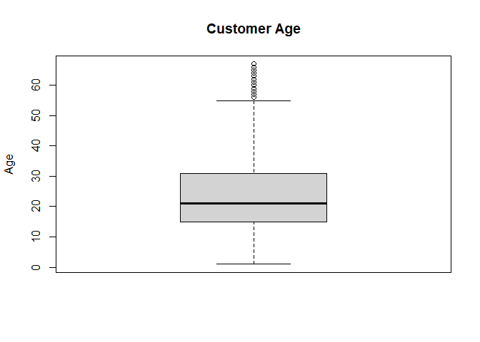

The boxplot above shows the distribution of the variable age and if it contains any outliers. It can be seen that the boxplot is skewed to the right and contains outliers at the upper end of the distribution.

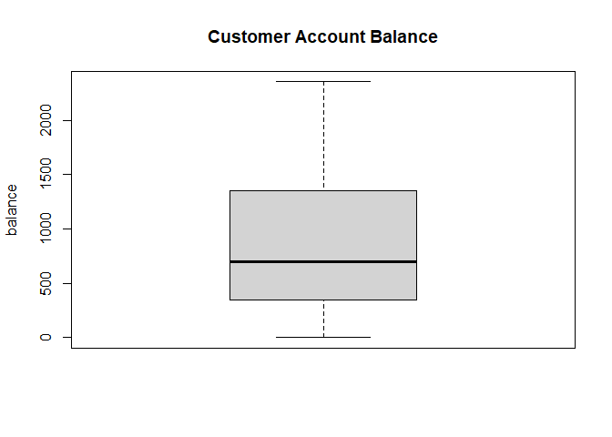

The boxplot above shows the distribution of the variable balance and if it contains any outliers. It can be seen that the boxplot is slightly skewed to the right. There are no outliers present.

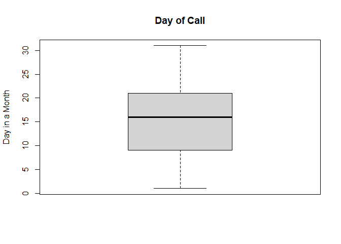

The boxplot above shows the distribution of the variable dat and if it contains any outliers. It can be seen that the boxplot looks normally distributed and contains no outliers.

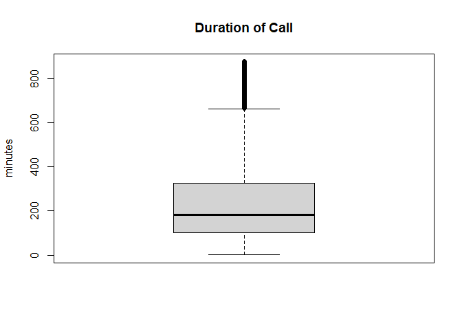

The boxplot above shows the distribution of the variable duration and if it contains any outliers. It can be seen that the boxplot is highly skewed to the right and contains many outliers at the upper end of the distribution.

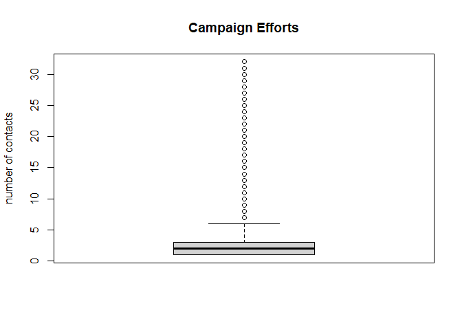

The boxplot above shows the distribution of the variable campaign and if it contains any outliers. It can be seen that the boxplot is skighly kewed to the right and contains many outliers at the upper end of the distribution.

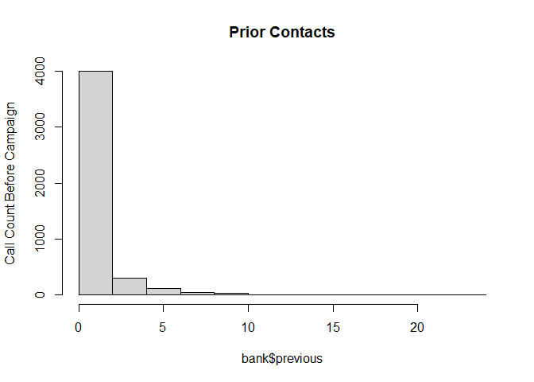

The histogram above shows the distribution of the variable previous. It can be seen that the distribution is highly skewed to the right.

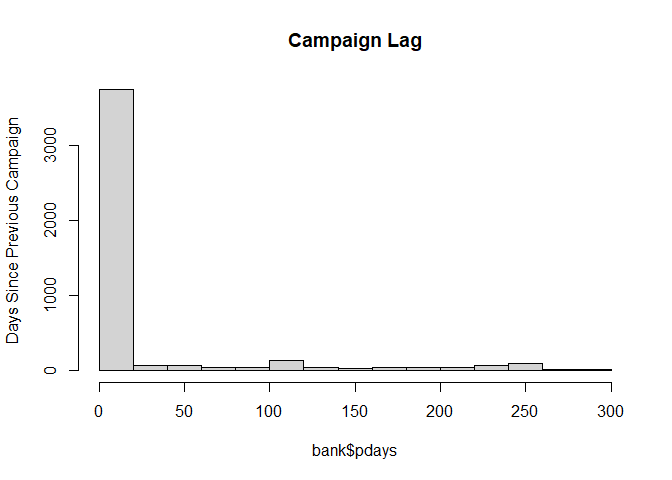

The histogram above shows the distribution of the variable pdays Similarly to the variable previous, the distribution is highly skewed to the right.

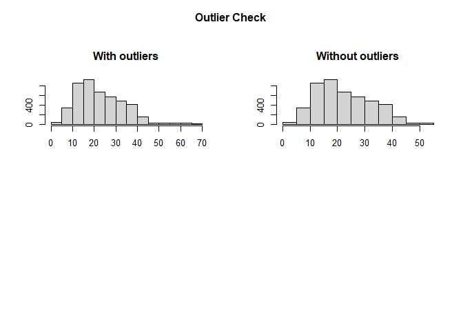

```r
bank2 = outlierKD2(bank, age, rm=T, histogram = T)
```

## QQ-plot

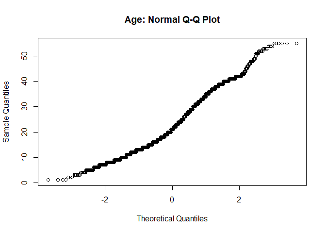

```r
qqnorm(bank2$age, main = "Age: Normal Q-Q Plot") + theme(plot.title = element_text(hjust = 0.5, face = "bold"))
```

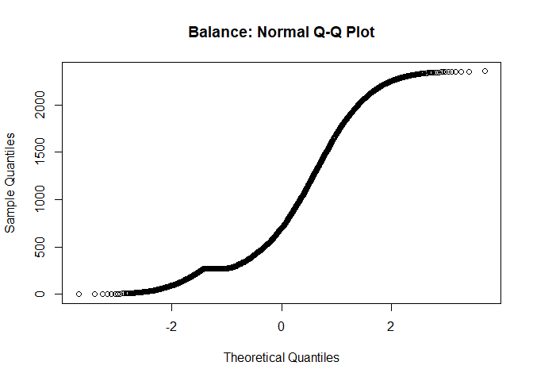

```r
qqnorm(bank2$balance, main = "Balance: Normal Q-Q Plot") + theme(plot.title = element_text(hjust = 0.5, face = "bold"))
```

The qq-plot above shows the distribution for the variable, balance. The plot indicates that it does not follow a normal distribution.

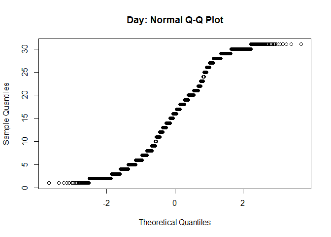

```r
qqnorm(bank2$day, main = "Day: Normal Q-Q Plot") + theme(plot.title = element_text(hjust = 0.5, face = "bold"))
```

The plot above shows that the variable day does not follow a normal distribution.

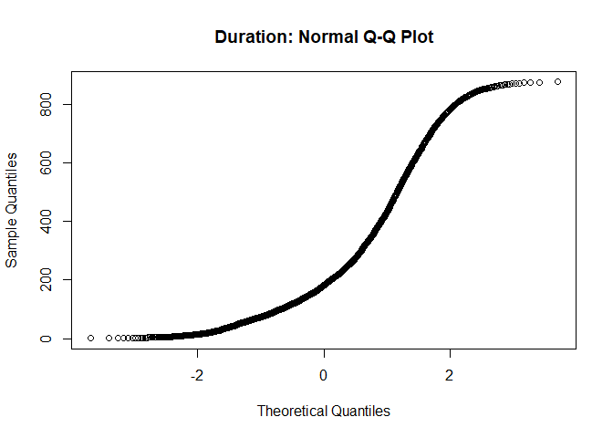

```r
qqnorm(bank2$duration, main = "Duration: Normal Q-Q Plot") + theme(plot.title = element_text(hjust = 0.5, face = "bold"))
```

The plot above shows that the variable duration does not follow a normal distribution.

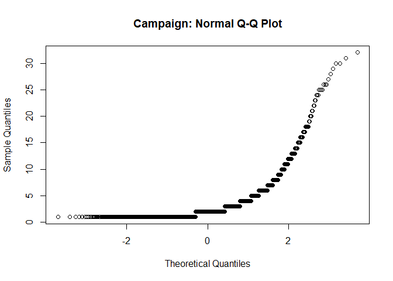

```r
qqnorm(bank2$campaign, main = "Campaign: Normal Q-Q Plot") + theme(plot.title = element_text(hjust = 0.5, face = "bold"))
```

The plot above shows that the variable campaign does not follow a normal distribution.

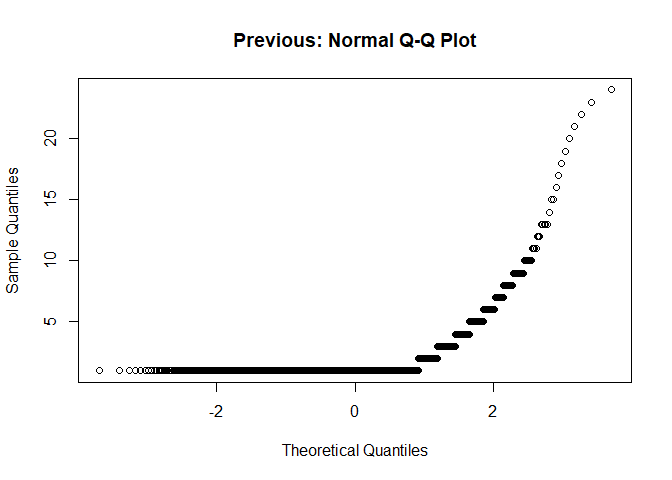

```r
qqnorm(bank2$previous, main = "Previous: Normal Q-Q Plot") + theme(plot.title = element_text(hjust = 0.5, face = "bold"))
```

The plot above shows that the variable previous does not follow a normal distribution

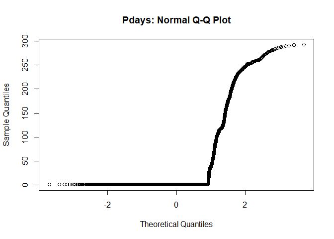

```r
qqnorm(bank2$pdays, main = "Pdays: Normal Q-Q Plot") + theme(plot.title = element_text(hjust = 0.5, face = "bold"))
```

The plot above shows that the variable pday does not follow a normal distribution.

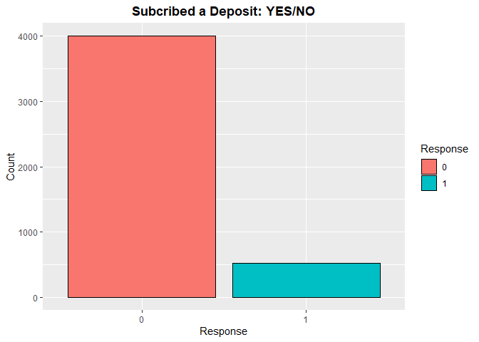

The bar chart above shows the number of yes-no responses from the deposit subscription survey. Red indicates a no response and green indicates a yes response. From the chart, it is evident that there were many more no responses than yes responses. This shows that the data is extremely imbalanced. The actual proportions are .885 no responses and .115 yes responses. 0 1 0.885 0.115

## Visualizations

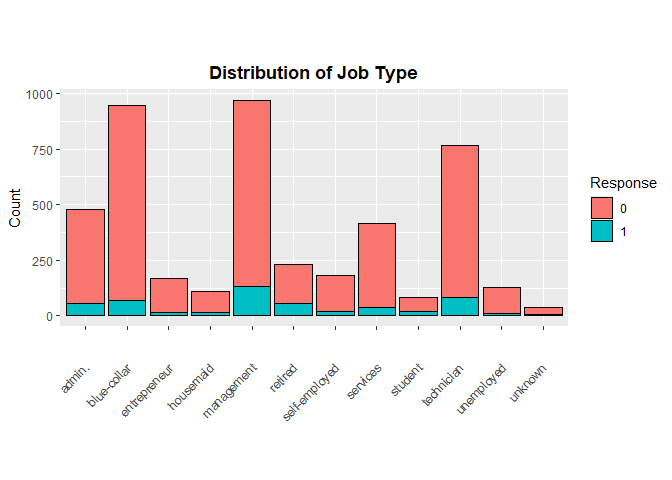

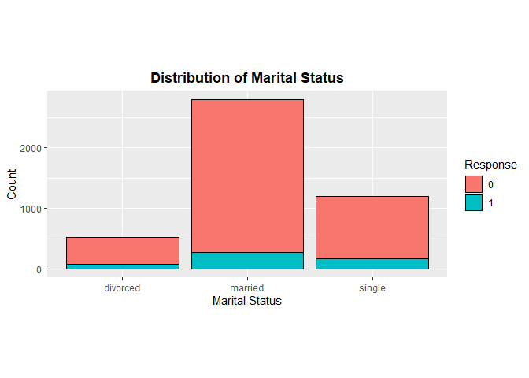

The bar chart above shows the distribution of survey responses based on marital status. Married individuals answered yes more frequently than single and divorced individuals. The vast majority of divorced individuals answered no.

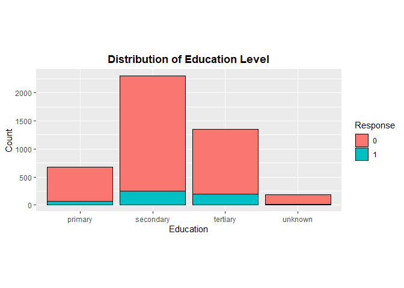

The bar chart above shows the distribution of yes and no responses based on education level. Individuals with secondary level education responded yes more frequently than individuals with primary, secondary, and unknown. The vast majority of individuals with only a primary level of education responded no. The same is the case for individuals with an unknown education level.

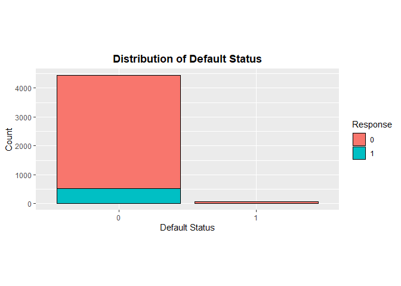

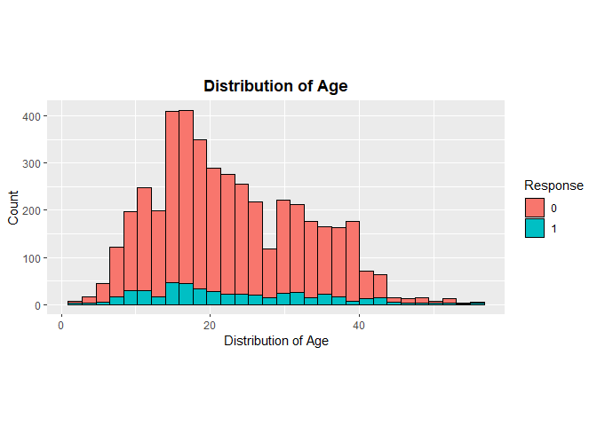

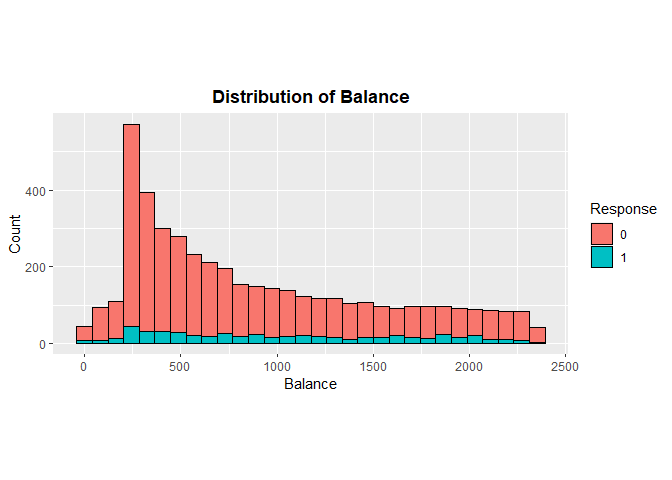

The histogram above shows the distribution of the balance of the individuals who responded to the survey. Most responses came from individuals with a balance of about $250. As the balance increases, the number of responses decreases. Individuals with a balance of about 250 gave the most yes responses, whereas almost no individuals with a 0 balance or a balance above about 2100 responded yes.

# Data Partition

Split the data set into training and test sets with the size of training set = 0.7.

```r
set.seed(123)
sample <- sample.split(bank2$y, SplitRatio = 0.7)
train <- subset(bank2, sample == TRUE)
test  <- subset(bank2, sample == FALSE)
```

# Model Construction

## Without balancing

Let’s start building the model with backward stepwise reduction using the training set. Here we would drop the column ‘job’, ‘day’ and ‘month’.

```
##
## Call:
## glm(formula = y ~ age + marital + education + default + balance +
##     housing + loan + contact + duration + campaign + pdays +
##     previous + poutcome, family = "binomial", data = train)
##
## Deviance Residuals:
##    Min      1Q  Median      3Q     Max
## -2.974  -0.373  -0.246  -0.160   3.019
##
## Coefficients:
##                     Estimate Std. Error z value Pr(>|z|)
## (Intercept)        -3.752695   0.560963   -6.69  2.2e-11 ***
## age                 0.006673   0.007731    0.86  0.38808
## maritalmarried     -0.271883   0.210924   -1.29  0.19739
## maritalsingle       0.134978   0.241157    0.56  0.57568
## educationsecondary  0.198424   0.224269    0.88  0.37629
## educationtertiary   0.355125   0.234215    1.52  0.12946
## educationunknown   -0.130526   0.393565   -0.33  0.74015
## default1            0.950861   0.475882    2.00  0.04571 *
## balance             0.000235   0.000108    2.18  0.02949 *
## housing1           -0.434015   0.148026   -2.93  0.00337 **
## loan1              -0.761204   0.230637   -3.30  0.00097 ***
## contacttelephone    0.060513   0.282838    0.21  0.83059
## contactunknown     -0.880191   0.196683   -4.48  7.6e-06 ***
## duration            0.005959   0.000310   19.19  < 2e-16 ***
## campaign           -0.067054   0.033185   -2.02  0.04332 *
## pdays              -0.001513   0.001729   -0.88  0.38136
## previous            0.041554   0.053410    0.78  0.43656
## poutcomeother       0.428355   0.336117    1.27  0.20251
## poutcomesuccess     2.494092   0.334207    7.46  8.5e-14 ***
## poutcomeunknown    -0.385429   0.375312   -1.03  0.30444
## ---
## Signif. codes:  0 '***' 0.001 '**' 0.01 '*' 0.05 '.' 0.1 ' ' 1
##
## (Dispersion parameter for binomial family taken to be 1)
##
##     Null deviance: 2211.1  on 3136  degrees of freedom
## Residual deviance: 1519.1  on 3117  degrees of freedom
##   (28 observations deleted due to missingness)
## AIC: 1559
##
## Number of Fisher Scoring iterations: 6
```

Unbalanced Model with Many Features

|  | Estimate | Std. Error | z value | Pr(>\|z\|) |
| --- | --- | --- | --- | --- |
| (Intercept) | -3.7527 | 0.5610 | -6.690 | 0.0000 |
| age | 0.0067 | 0.0077 | 0.863 | 0.3881 |
| maritalmarried | -0.2719 | 0.2109 | -1.289 | 0.1974 |
| maritalsingle | 0.1350 | 0.2412 | 0.560 | 0.5757 |
| educationsecondary | 0.1984 | 0.2243 | 0.885 | 0.3763 |
| educationtertiary | 0.3551 | 0.2342 | 1.516 | 0.1295 |
| educationunknown | -0.1305 | 0.3936 | -0.332 | 0.7402 |
| default1 | 0.9509 | 0.4759 | 1.998 | 0.0457 |
| balance | 0.0002 | 0.0001 | 2.177 | 0.0295 |
| housing1 | -0.4340 | 0.1480 | -2.932 | 0.0034 |
| loan1 | -0.7612 | 0.2306 | -3.300 | 0.0010 |
| contacttelephone | 0.0605 | 0.2828 | 0.214 | 0.8306 |
| contactunknown | -0.8802 | 0.1967 | -4.475 | 0.0000 |
| duration | 0.0060 | 0.0003 | 19.194 | 0.0000 |
| campaign | -0.0671 | 0.0332 | -2.021 | 0.0433 |
| pdays | -0.0015 | 0.0017 | -0.875 | 0.3814 |
| previous | 0.0416 | 0.0534 | 0.778 | 0.4366 |
| poutcomeother | 0.4284 | 0.3361 | 1.274 | 0.2025 |
| poutcomesuccess | 2.4941 | 0.3342 | 7.463 | 0.0000 |
| poutcomeunknown | -0.3854 | 0.3753 | -1.027 | 0.3044 |

```
##
## Call:
## glm(formula = y ~ balance + housing + loan + duration + campaign,
##     family = "binomial", data = train)
##
## Deviance Residuals:
##    Min      1Q  Median      3Q     Max
## -1.933  -0.425  -0.297  -0.204   2.772
##
## Coefficients:
##              Estimate Std. Error z value Pr(>|z|)
## (Intercept) -3.41e+00   1.85e-01  -18.47  < 2e-16 ***
## balance      3.10e-04   9.73e-05    3.19  0.00144 **
## housing1    -7.62e-01   1.28e-01   -5.94  2.8e-09 ***
## loan1       -8.45e-01   2.19e-01   -3.85  0.00012 ***
## duration     5.55e-03   2.82e-04   19.71  < 2e-16 ***
## campaign    -1.01e-01   3.29e-02   -3.08  0.00208 **
## ---
## Signif. codes:  0 '***' 0.001 '**' 0.01 '*' 0.05 '.' 0.1 ' ' 1
##
## (Dispersion parameter for binomial family taken to be 1)
##
##     Null deviance: 2263.0  on 3164  degrees of freedom
## Residual deviance: 1738.5  on 3159  degrees of freedom
## AIC: 1750
##
## Number of Fisher Scoring iterations: 6
```

Refined Model After Stepwise Reduction

|  | Estimate | Std. Error | z value | Pr(>\|z\|) |
| --- | --- | --- | --- | --- |
| (Intercept) | -3.4096 | 0.1846 | -18.47 | 0.0000 |
| balance | 0.0003 | 0.0001 | 3.19 | 0.0014 |
| housing1 | -0.7615 | 0.1282 | -5.94 | 0.0000 |
| loan1 | -0.8446 | 0.2191 | -3.85 | 0.0001 |
| duration | 0.0055 | 0.0003 | 19.71 | 0.0000 |
| campaign | -0.1012 | 0.0329 | -3.08 | 0.0021 |

Balance, housing, loan, duration, campaign are statistically significant predictors. Balance and duration have positive coefficients meaning y is associated with higher balance and longer calls. Housing, loan, and campaign have negative coefficients, meaning y is associated with not having housing, not having loan and fewer times of campaign.

## Balance the dataset

Since our training set is extremely unbalanced, with far more 0’s than 1’s in y, let’s construct a model with a more balanced training set. Here, using the `ovun.sample` function in the `ROSE` package, we would under-sample cases of 0 and over-sample cases of 1.

Construct the model with the balanced dataset.

```
##
## Call:
## glm(formula = y ~ balance + housing + loan + duration + campaign,
##     family = "binomial", data = bank_balanced_over)
##
## Deviance Residuals:
##    Min      1Q  Median      3Q     Max
## -2.922  -0.778   0.196   0.792   2.049
##
## Coefficients:
##              Estimate Std. Error z value Pr(>|z|)
## (Intercept) -1.53e+00   9.02e-02  -16.92  < 2e-16 ***
## balance      3.12e-04   5.29e-05    5.89  3.8e-09 ***
## housing1    -7.66e-01   6.72e-02  -11.40  < 2e-16 ***
## loan1       -1.00e+00   1.11e-01   -9.07  < 2e-16 ***
## duration     6.37e-03   1.81e-04   35.19  < 2e-16 ***
## campaign    -1.36e-01   1.51e-02   -9.04  < 2e-16 ***
## ---
## Signif. codes:  0 '***' 0.001 '**' 0.01 '*' 0.05 '.' 0.1 ' ' 1
##
## (Dispersion parameter for binomial family taken to be 1)
##
##     Null deviance: 7763.0  on 5599  degrees of freedom
## Residual deviance: 5532.9  on 5594  degrees of freedom
## AIC: 5545
##
## Number of Fisher Scoring iterations: 5
```

Model from Balanced Dataset

[output not shown]

### Training Set’s Predicted Score

We’ll perform a quick evaluation on the training set by plotting the probability (score) estimated by our model with a double density plot.

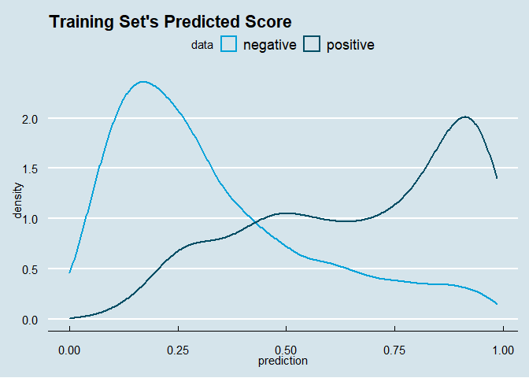

Given that our model’s final objective is to classify new instances into one of two categories, whether the client will subscribe to a term deposit, we will want the model to give high scores to positive instances and low scores otherwise. Thus for a ideal double density plot you want the distribution of scores to be separated, with the score of the negative instances to be on the left and the score of the positive instance to be on the right. In this case, our model indeed displays this pattern.

# Cost of our models

Our objective is choosing a cutoff that minimizes the cost of our models on the test set generated from FP’s and FN’s.

## Unbalanced model

### Confusion matrix at cutoff = 0.5

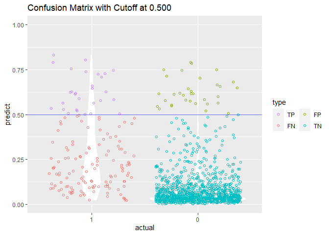

```r
table(result$type)
```

```
##
##   FN   FP   TN   TP
##  127   33 1167   29
```

### Optimal cutoff & minimal cost

In our case, an FN means that a client subscribed to a term deposit but our model fails to detect that. This is an expensive mistake because it means our client is not taken care of. Our bank have to compensate a lot for their mistake and the client may not choose any service from our bank in the future. An FP means that a client did not subscribe to a term deposit and our model told us that they did. As for conducting this kind of mistake, we might simply waste 5 minutes on a phone call with someone who did not choose our service.

Let’s assign a value to FP and FN and compute the cost. Here we let the cost of FN be 200 and the cost of FP be 100.

```r
library(ROCR)
cost.fp <- 100
cost.fn <- 200
pred <- prediction(test$banklogpred, test$y)
perf <- performance(pred,"tpr","fpr")
roc_dt <- data.frame( fpr = perf@x.values[[1]], tpr = perf@y.values[[1]] )
cost <- perf@x.values[[1]] * cost.fp * sum( test$y == 0 ) +
            ( 1 - perf@y.values[[1]] ) * cost.fn * sum( test$y == 1 )
cost_dt <- data.frame( cutoff = pred@cutoffs[[1]], cost = cost )
best_index  <- which.min(cost)
best_cost   <- cost_dt[ best_index, "cost" ]
best_tpr    <- roc_dt[ best_index, "tpr" ]
best_fpr    <- roc_dt[ best_index, "fpr" ]
best_cutoff <- pred@cutoffs[[1]][ best_index ]
best_cost
```

```
## [1] 26200
```

```r
best_cutoff
```

```
## [1] 0.199
```

### ROC plot & Cost plot

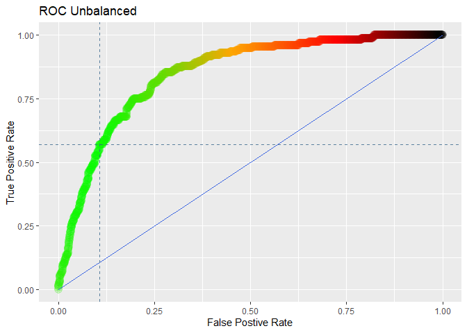

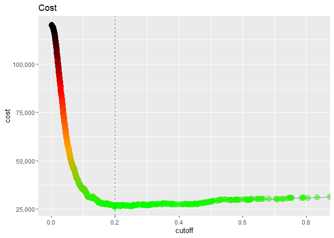

The cost plot calculates the the associated cost for choosing different cutoff value and the optimal cutoff is at 0.199.

Reconstruct the confusion matrix at the opitmal cutoff (of the cost function).

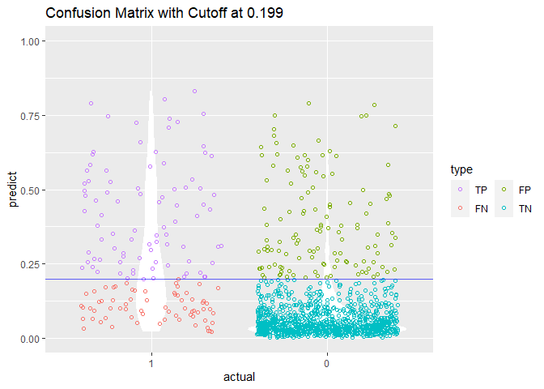

```r
table(result$type)
```

```
##
##   FN   FP   TN   TP
##   68  128 1072   88
```

## Balanced model

### Confusion matrix at cutoff = 0.5

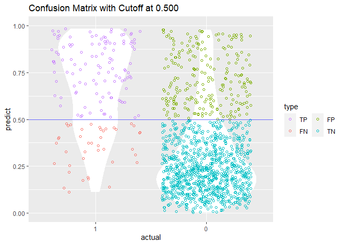

With a balanced dataset, we have fewer cases of FN, but more cases of FP. We want to see if by raising the cutoff, we can decrease the cases of FP significantly by have a reasonably more cases of FN.

Below are the exact number of each type of case.

```r
table(result$type)
```

```
##
##  FN  FP  TN  TP
##  41 236 964 115
```

### Optimal cutoff & minimal cost

```r
cost.fp <- 100
cost.fn <- 200
# At cutoff = 0.5, cost = 200* 41 + 100 * 236 = 31800
pred <- prediction(test$prediction, test$y)
perf <- performance(pred,"tpr","fpr")
roc_dt <- data.frame( fpr = perf@x.values[[1]], tpr = perf@y.values[[1]] )
cost <- perf@x.values[[1]] * cost.fp * sum( test$y == 0 ) +
            ( 1 - perf@y.values[[1]] ) * cost.fn * sum( test$y == 1 )
cost_dt <- data.frame( cutoff = pred@cutoffs[[1]], cost = cost )
best_index  <- which.min(cost)
best_cost   <- cost_dt[ best_index, "cost" ]
best_tpr    <- roc_dt[ best_index, "tpr" ]
best_fpr    <- roc_dt[ best_index, "fpr" ]
best_cutoff <- pred@cutoffs[[1]][ best_index ]
best_cost
```

```
## [1] 25800
```

```r
best_cutoff
```

```
## [1] 0.703
```

The optimal cutoff is 0.703. The minimal cost is 25800. At cutoff = 0.5, the cost is 31800.

### ROC plot & Cost plot

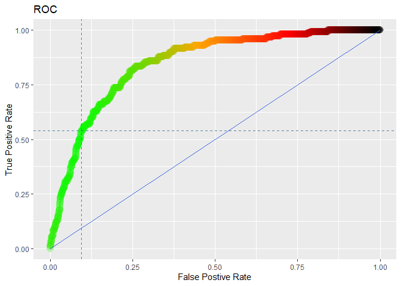

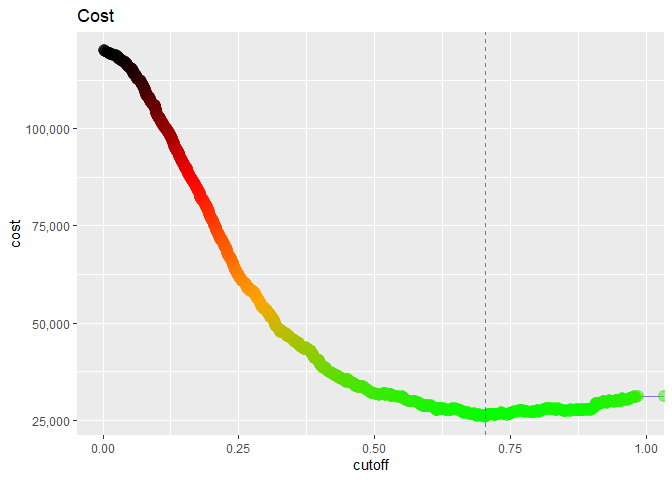

The cost plot implies that the optimal cutoff is at 0.703. This is the most realistic cutoff we would choose since in real-life scenarios we may associate a 70% probability to success.

Reconstruct the confusion matrix at the optimal cutoff (of the cost function).

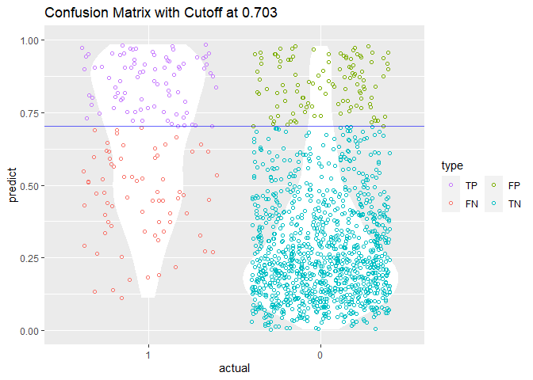

```r
table(result$type)
```

```
##
##   FN   FP   TN   TP
##   72  114 1086   84
```

We have 31 more cases of FN but only less than half the cases of FP. We also reduce the cost by 6000.

# Interpretation and Reasoning

## McFadden

```r
pR2(mybanklog2b)
```

```
## fitting null model for pseudo-r2
```

```
##       llh   llhNull        G2  McFadden      r2ML      r2CU
## -2766.427 -3881.521  2230.188     0.287     0.329     0.438
```

## Predictors importance

We would like to determine the relative importance of predictors in our model.

### Deviance

Let’s first interpret the table of null deviance.

```r
anova(mybanklog2b, test="Chisq")
```

```
## Analysis of Deviance Table
##
## Model: binomial, link: logit
##
## Response: y
##
## Terms added sequentially (first to last)
##
##
##          Df Deviance Resid. Df Resid. Dev Pr(>Chi)
## NULL                      5599       7763
## balance   1       64      5598       7699  1.2e-15 ***
## housing   1      100      5597       7599  < 2e-16 ***
## loan      1       52      5596       7546  4.8e-13 ***
## duration  1     1925      5595       5622  < 2e-16 ***
## campaign  1       89      5594       5533  < 2e-16 ***
## ---
## Signif. codes:  0 '***' 0.001 '**' 0.01 '*' 0.05 '.' 0.1 ' ' 1
```

### Dominance analysis

#### Complete dominance matrix

Here is the complete dominance matrix.

```r
dominanceMatrix(dabank, type="complete",fit.functions = "r2.m", ordered=TRUE)
```

```
##          duration housing loan campaign balance
## duration      0.5     1.0  1.0      1.0     1.0
## housing       0.0     0.5  1.0      1.0     1.0
## loan          0.0     0.0  0.5      0.5     1.0
## campaign      0.0     0.0  0.5      0.5     0.5
## balance       0.0     0.0  0.0      0.5     0.5
```

This matrix summarizes the relation between each pair of predictors. If the value between two predictors is 1, the predictor under the first column completely dominates the other predictor of the pair. If the value is 0, the predictor under the first column is completely dominated by the other predictor of the pair. Lastly, if the value is 0.5, complete dominance could not be established between the pair.

#### General dominance plot

```r
averageContribution(dabank, fit.functions = "r2.m")
```

```
##
## Average Contribution by predictor
##      balance housing loan duration campaign
## r2.m   0.006   0.016 0.01    0.245     0.01
```

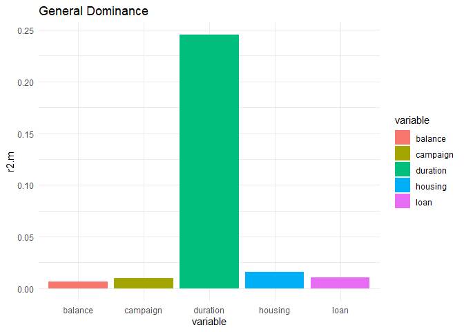

```r
plot(dabank, which.graph ="general",fit.function = "r2.m")
```

# Conclusion

Lastly, by conducting a dominance analysis, we found that the single most important predictor in our model was duration of the call. This has major implications for marketing campaigns – namely the longer a telemarketer can keep a customer on the phone, the more likely they are to purchase or subscribe to a product.

Based on our findings, we hope that this Portuguese bank can more effectively target their advertising campaigns, decrease costs, and increase their revenue.

# Reference

Bank Marketing Campaign https://www.kaggle.com/edith2021/bank-marketing-campaign

Useful functions when working with logistic regression https://github.com/ethen8181/machine-learning/blob/master/unbalanced/unbalanced_code/unbalanced_functions.R

Exploring predictors’ importance in binomial logistic regressions https://cran.r-project.org/web/packages/dominanceanalysis/vignettes/da-logistic-regression.html